# **Aplicaciones de las Redes Neurales**

**Basado en el proyecto del Módulo 5 Bootcamp de Ciencia de Datos e Inteligencia Artificial**

## Red Neuronal *Feedforward*

La propagación de *fake news* o noticias falsas se incrementó a partir de la pandemia por COVID-19. Estas son un problema alarmante porque hacen que las personas realicen actividades que normalmente no llevarían a cabo o que actúen de manera caótica. Un ejemplo es [-> esta noticia <-](https://drive.google.com/file/d/1PrfN83Fm1ib5mHYN6SULVe9CJVECUNn2/view?usp=share_link), en la que se relata cómo notas falsas acerca del daño que ocasiona la 5G al cuerpo provocaron que muchas personas en el Reino Unido quemaran torres de telecomunicaciones aun sin ser estas de 5G.

A ti, como persona experta en redes neuronales, te han encargado hacer un predector de noticias falsas para los *fact-checker* del mundo.

Para realizarlo, tienes a tu disposición el siguiente *dataset*: https://www.kaggle.com/datasets/saurabhshahane/fake-news-classification

|  | Unnamed: 0 | title | text | label |
| --- | --- | --- | --- | --- |
| 0 | 0 | LAW ENFORCEMENT ON HIGH ALERT Following Threat... | No comment is expected from Barack Obama Membe... | 1 |
| 1 | 1 | NaN | Did they post their votes for Hillary already? | 1 |
| 2 | 2 | UNBELIEVABLE! OBAMA’S ATTORNEY GENERAL SAYS MO... | Now, most of the demonstrators gathered last ... | 1 |
| 3 | 3 | Bobby Jindal, raised Hindu, uses story of Chri... | A dozen politically active pastors came here f... | 0 |
| 4 | 4 | SATAN 2: Russia unvelis an image of its terrif... | The RS-28 Sarmat missile, dubbed Satan 2, will... | 1 |

### Distribución de clases

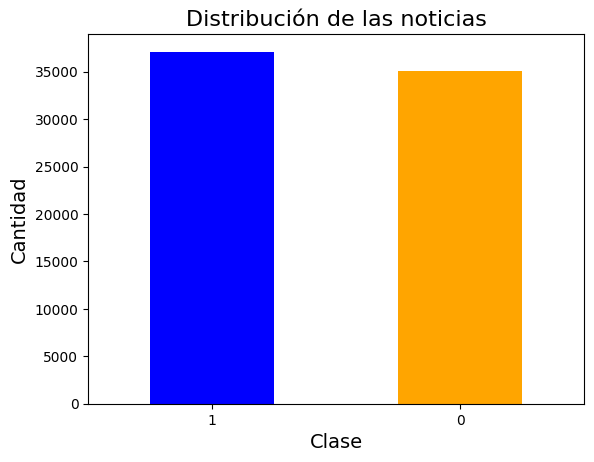

```
1    37106
0    35028
Name: label, dtype: int64
```

Del diagrama de barras es posible evidenciar que el número de *fake news* o noticias falsas (`clase` $= 1$) es de 37.106, lo cual es algo mayor que las noticias verdaderas (`clase` $= 0$), 35.028. Sin embargo, no hay un desbalance evidente entre las clases.

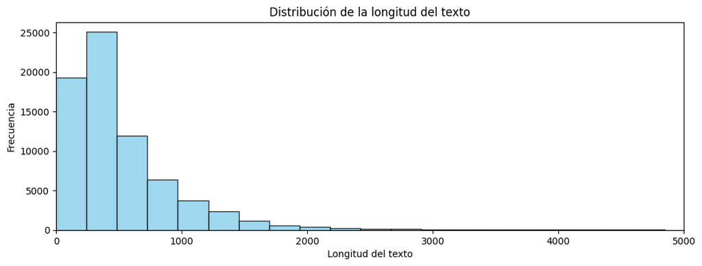

```
count    72134.000000
mean       540.551474
std        625.399281
min          0.000000
25%        227.000000
50%        398.000000
75%        667.000000
max      24234.000000
Name: length, dtype: float64
```

Se puede observar que el total de los textos es de un total de 72.134, siendo la media por noticia de 540. No obstante, se evidencia que hay presencia de *outliers* o valores atípicos por dos razones:

- En el histograma es posible observar como algunas de las noticias tienen entre 2.000 y 3.000 palabras, mientras que la mayoría tienen máximo 1.000.
- La media aritmética, que es sensible a los *outliers*, es mucho mayor que la mediana o el percentil 50 (398), que es insensible a estos.

No obstante, el eliminar los outliers en este modelo puede llevar al modelo a subestimar los resultados, ya que la longitud de las noticias implica una variablidad importante y, por ende, una cantidad de información que se puede perder en caso de elimnar los outliers. Otra razón para no eliminarlos es que las clases no están desbalanceadas, por lo que puede no haber un efecto negativo para el modelo en caso de dejarlos.

### Análisis de las palabras más frecuentes

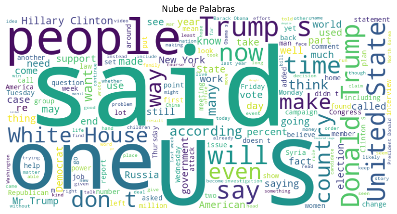

Después de eliminar las filas con valores nulos o `NaN`, la nube de palabras muestra las palabras más frecuentes en las noticias, en función del tamaño de las palabras en el lienzo, por lo que se puede ver que algunas de las palabras más frecuentes son: *US*, *said*, *one*, *Trump* (por lo que es posible inferir que este dataframe fue realizado durante su presidencia), entre otros.

### Procesamiento del texto (Tokenización)

El tamaño del vocabulario a utlizar para entrenar el modelo es de las 10.000 palabras más frecuentes, estableciendo una longitud máxima de las secuencias de palabras de 500.

Con el token implementado, se procede a convertir cada texto en la columna en una secuencia de números enteros, donde cada uno representa una palabra del vocabulario.

### Diseño y entrenamiento del modelo

Se decide diseñar un modelo de redes neurales recurrentes empleando `Keras`, el cual utiliza una capa de *embedding* para convertir las palabras en vectores, seguidos de una capa de *Long Short-Term Memory* para capturar distintos patrones en las secuencias de texto.

Además, se agregan capas densas para compilarlar mediante el optimizados `Adam` y la funciónd de pérdida `binary_crossentropy`, puesto que se trata de un problema de clasificación binaria.

Finalmente, se deciden utlizar 10 épocas para entrenar el modelo, con el fin de adaptar la complejidad del problema debido al tamaño del cnojunto de datos, con las características propias del sistema, es decir, se plantea encontrar un punto de equilibrio entre la complejidad del modelo y el tiempo de entrenamiento.

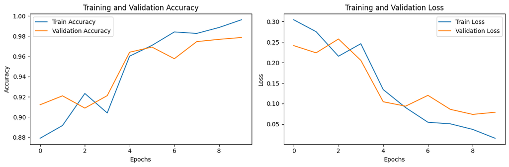

De las gráficas es posible observar que la precisión del conjunto de entrenamiento frente al de validación es un poco mayor ($\pm2.5$%), pero ambos conjuntos tienen una alta precisión ($97.5\% \leq \text{accuracy} \leq 99.9\%$). Por otro lado, en cuanto a la pérdida del modelo, es claro que el conjunto de entrenamiento tiene una menor pérdida en relación a las épocas implementadas frente al conjunto de validación, sin embargo no es muy grande la diferencia.

Con base en lo anterior, es posible concluir que el modelo entrenado tiene una gran adaptación al modelo, además de evitar el sobreajuste y lograr una alta precisión en la clasificación.

### Evaluación del modelo

```
Test Loss: 0.08543536812067032
Test Accuracy: 0.9775296449661255
Fake News Prediction: 0.9999055862426758
True News Prediction: 0.9992165565490723
```

Al evaluar el modelo, se observa que su pérdida es del 8%, mientras que su precisión ronda el 97% en datos no vistos.

Posteriormente, se utiliza el modelo para determinar la veracidad de dos noticias, es decir, su capacidad para clasificar correctamente una noticia falsa como falsa y una noticia verdadera como verdadera.

## Red Neuronal Convolucional

Se acerca el fin de año y con ello la necesidad de realizar los balances generales, estados financieros, etc. Una empresa te contrata para capturar manualmente todos sus recibos de ventas, solo que hay un pequeño problema: todos están hechos a mano, por lo que sería muy tardado ver recibo tras recibo y capturarlos de forma manual.

Sin embargo, recuerdas que aprendiste acerca de las redes neuronales convolucionales. Por ello, decides hacer un modelo que afronte este problema con Inteligencia Artificial y que convierta la escritura a mano en caracteres.

Tienes el *dataset* de dígitos escritos a mano de Mnist a tu disposición: https://www.tensorflow.org/datasets/catalog/mnist.

### Visualización de datos

```
Downloading data from https://storage.googleapis.com/tensorflow/tf-keras-datasets/mnist.npz
```

```
28
```

```
Ingresa un número 15
```

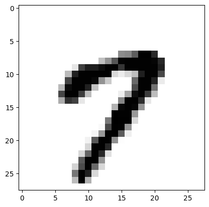

```
(None, 7)
```

### Creación e implementación del modelo

Al implementar el modelo de redes neurales convulcionales para el procesamiento de imágenes, se escogen 12 épocas, es decir, donde el modelo ajusta sus pesos y aprende de los datos.

Al observar los resultados de cada época, se puede observar que la pérdida disminuye gradualmente, lo cual indica que el modelo está mejorando su capacidad para hacer predicciones más precisas. Al mismo tiempo, la precisión también aumenta, mostrando la proporción de predicciones correctas respecto al total de muestras.

De manera que se decidió utlizar 12 épocas porque a medida que se entrenaba el modelo, la pérdida disminuía mientras la precisión aumentaba, pero entre más épocas, el cambio en las variables disminuía, por lo que aumentar más épocas solo lograrían incrementar la complejidad del modelo y, por ende, un mayor gasto de los recursos computacionales sin haber una mejora importante en la capacidad de este.

### Métricas del modelo

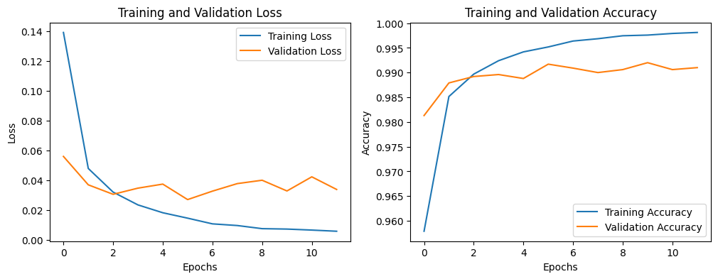

Los gráficos de pérdida y precisión muestran que la diferencia entre el conjunto de entrenamiento y validación no es muy alta ($\pm2$%), por lo que no hay evidencia de que se haya producido un overfitting o sobreajuste de los datos.

En la gráfica de pérdida, se puede ver que en ambos conjuntos la pérdida es menor del 10%, siendo algo menor en el conjunto de entrenamiento, lo cual es esperable. Por otro lado, en la gráfica de precisión, se evidencia que ambos conjuntos tienen una alta precisión, superando en ambos casos el 98%.

### Evaluación del modelo

```
Ingresa un número: 14
Etiquetas Predichas: [7, 2, 1, 0, 4, 1, 4, 9, 5, 9, 0, 6, 9, 0]

Etiquetas Verdaderas: [7 2 1 0 4 1 4 9 5 9 0 6 9 0]
```

[output not shown]